# The DADA2 R package

## Fast, accurate, single-nucleotide resolution for amplicon data

## Installation

Binaries for the current release version of DADA2 (1.2) are available from Bioconductor (note that you must have R 3.3.1 or newer, and [Biocondcutor version 3.4](https://www.bioconductor.org/install/), to install the current release from Bioconductor):

```
## try http:// if https:// URLs are not supported
source("https://bioconductor.org/biocLite.R")
biocLite("dada2")
```

If you wish to install the latest and greatest development version, or to install to R 3.2, see our from-source installation instructions.

## Tutorials

**Start here:** The DADA2 tutorial goes through a typical workflow for paired end Illumina Miseq data: raw amplicon sequence data is processed into the table of biological sequence variants (SVs) present in each sample.

The DADA2 Workflow on Big Data goes through workflow optimized to run on large datasets (10s of millions to billions of reads).

Short demonstrations of assigning taxonomy and assigning species to sequences.

## Benchmarking

Our [manuscript](http://dx.doi.org/10.1038/nmeth.3869) compares the accuracy of DADA2 and other methods on several mock community datasets. Further benchmarking of DADA2 against the methods evaluated in a recent QIIME1 benchmarking paper is also available. And sometimes a picture says a thousand word:

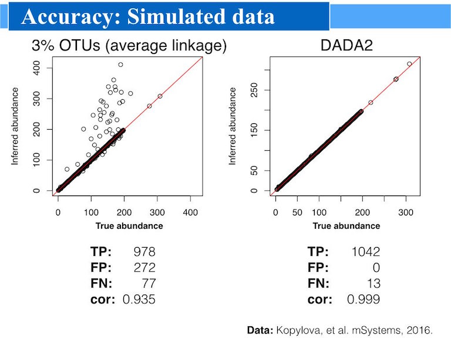

## Advantages

- DADA2 infers exact sequence variants from Illumina amplicon data. Even if sequence variants differ by 1 or 2 nucleotides, DADA2 resolves them.
- DADA2 reports fewer false sequence variants than other methods report false OTUs.
- The computational costs of DADA2 scale linearly with the number of samples, and DADA2’s memory requirements can remain essentially flat.
- DADA2 is open source software, licensed under the [LGPL version 3](http://www.gnu.org/licenses/lgpl-3.0.en.html).

## Support and Development

Planned feature improvements are publicly catalogued at the main DADA2 development site on github; specifically on the [issues tracker for DADA2](https://github.com/benjjneb/dada2/issues). If the feature you are hoping for is not listed, you are welcome to add it as a feature request on this page.

Bug reports and problems using DADA2 are also welcome on [the issues tracker](https://github.com/benjjneb/dada2/issues). We prefer posting to the issue tracker over email as these posts are searchable by other users who may experience the same problems.

## How?

**Accuracy:** DADA2’s crucial advantage is that it uses more of the data. The DADA2 error model incorporates quality information, which is ignored by all other methods after filtering. The DADA2 error model incorporates quantitative abundances, whereas most other methods use abundance ranks if they use abundance at all. The DADA2 error model identifies the differences between sequences, eg. A->C, whereas other methods merely count the mismatches. DADA2 can parameterize its error model from the data itself, rather than relying on previous datasets that may or may not reflect the PCR and sequencing protocols used in your study.

**Performance:** DADA2’s performance gains come from the fact that it infers sequences exactly rather than constructing OTUs. De novo OTUs cannot be compared across samples unless all samples were pooled during OTU construction. However, exact sequences **are** comparable across samples, as exact sequences are consistent labels. Thus DADA2 can analyze each sample independently, resulting in linear scaling with sample number and trivial parallelization.

Maintained by Benjamin Callahan (benjamin DOT j DOT callahan AT gmail DOT com)